# Text Analysis Notebook

In this notebook we analyse the content of the tweets. We want to understand which are the main topics discussed and their corresponding development over time.

## Prepare Notebook

```r
knitr::opts_knit$set(warning=FALSE, message=FALSE)

set.seed(seed = 42)

if(!require(igraph)) install.packages("igraph",repos = "http://cran.us.r-project.org")
library("igraph")
if(!require(magrittr)) install.packages("magrittr",repos = "http://cran.us.r-project.org")
library("magrittr")
if(!require(lubridate)) install.packages("lubridate",repos = "http://cran.us.r-project.org")
library("lubridate")
if(!require(tidytext)) install.packages("tidytext",repos = "http://cran.us.r-project.org")
library("tidytext")
if(!require(tidyverse)) install.packages("tidyverse",repos = "http://cran.us.r-project.org")
library("tidyverse")
if(!require(tm)) install.packages("tm",repos = "http://cran.us.r-project.org")
library("tm")
if(!require(topicmodels)) install.packages("topicmodels",repos = "http://cran.us.r-project.org")
library("topicmodels")
if(!require(widyr)) install.packages("widyr",repos = "http://cran.us.r-project.org")
library("widyr")
if(!require(wordcloud)) install.packages("wordcloud",repos = "http://cran.us.r-project.org")
library("wordcloud")

source(file = "../R/hashtags.R")
source(file = "../R/newtheme.R")
source(file = "../R/text_cleaning.R")
source(file = "../R/text_mining.R")
```

## Read Data

We read the pre-processed data obtanied from `R/data_processed.R`.

```r
#tweets_text_df <- readRDS(file = "/Users/sebastianmartinez/Dropbox/0. UoG/Projects/twitter_21n_data/tweets_text_df.rds")
tweets_text_df <- readRDS(file = "../data/tweets_text_df.rds")
#hashtags_count_df <- readRDS(file = "/Users/sebastianmartinez/Dropbox/0. UoG/Projects/twitter_21n_data/hashtags_count.rds")
hashtags_count_df <- readRDS(file = "../data/hashtags_count.rds")
```

## Tracked Hashtags

In the data gathering phase we tracked the following hashtags:

```r
twitter_terms <- c(
  "21N",
  "#21N",
  "#21NSomosTodos",
  "#Paro21N",
  "#YoMarchoEste21",
  "#YoMarchoEl21",
  "#YoNoMarchoEste21",
  "#YoNoMarchoEl21",
  "#RazonesParaMarchar",
  "#RazonesParaNoMarchar",
  "#100RazonesParaMarchar",
  "#100RazonesParaNoMarchar",
  "#YoNoParo",
  "#YoParoEl21NSinMiedo",
  "#Cacerolazo",
  "#22N",
  "#23N",
  "#ToqueDeQueda"
)
```

Let us see the top hastags appearing in the data:

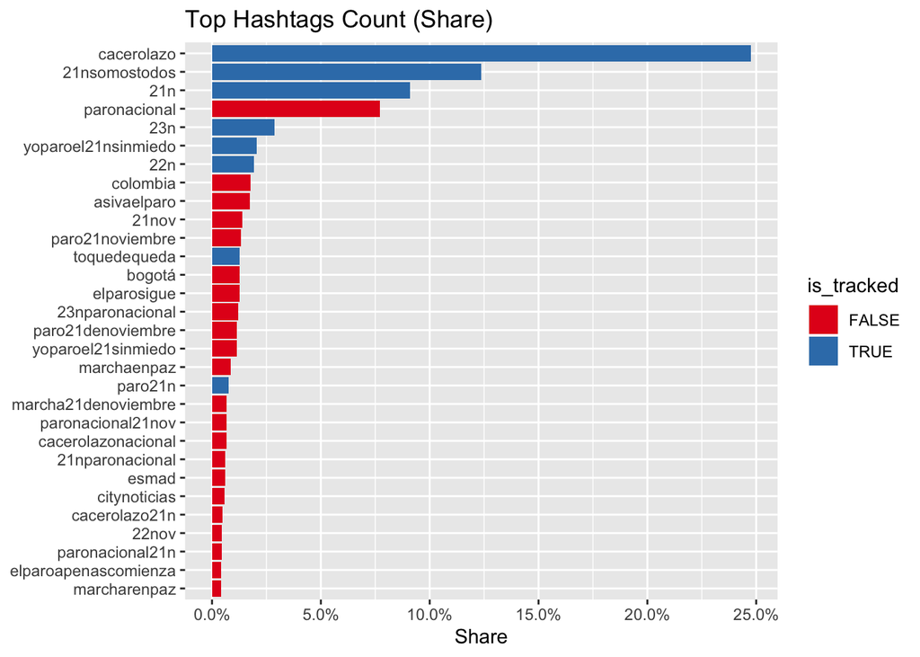

```r
normalized_twitter_terms <- twitter_terms %>%
  str_to_lower() %>%
  str_remove_all(pattern = "#")

hashtags_count_df %>%
  mutate(is_tracked = hashtag %in% normalized_twitter_terms) %>%
  mutate(n = n /sum(n)) %>%
  top_n(n = 30, wt = n) %>%
  mutate(hashtag = reorder(hashtag, n)) %>%
  ggmyplot(aes(x = hashtag, y = n, fill = is_tracked)) +
  geom_col() +
  xlab(NULL) +
  coord_flip() +
  ggtitle(label = "Top Hashtags Count (Share)") +
  ylab("Share") +
  scale_y_continuous(labels = scales::percent)
```

## Tweets Over Time

Let us see the time development of these hashtags over time (which has already been converted into Colombian local time):

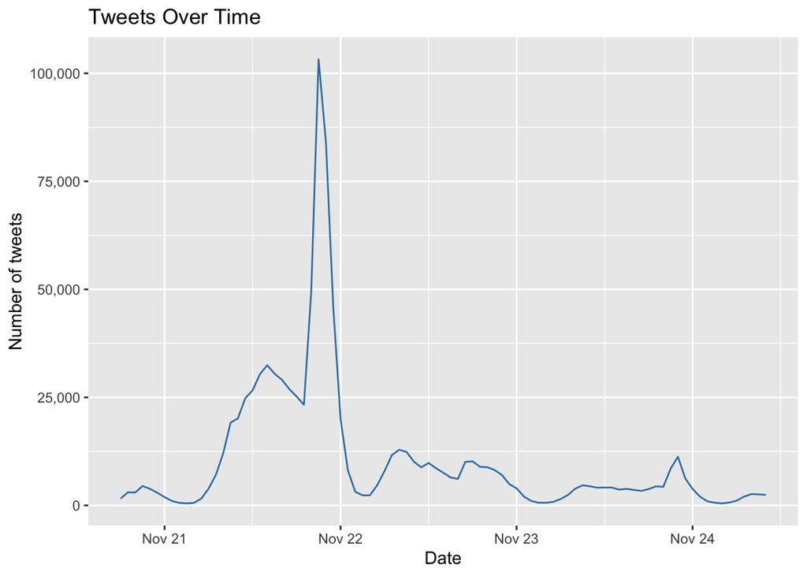

```r
tweets_text_df %>%
  count(created_at_round_hour) %>%
  ggmyplot(mapping = aes(x = created_at_round_hour, y = n)) +
  geom_line(color = PALETTE_SET1[2]) +
  labs(title = "Tweets Over Time") +
  xlab("Date") +
  ylab("Number of tweets") +
  scale_y_continuous(labels = scales::comma)
```

We see a remarkable peak. Let us find the time it happened:

```r
tweets_text_df %>%
  count(created_at_round_hour) %>%
  arrange(-n) %>%
  head(5)
```

```
## # A tibble: 5 x 2
##   created_at_round_hour      n
##   <dttm>                 <int>
## 1 2019-11-21 21:00:00   103238
## 2 2019-11-21 22:00:00    84023
## 3 2019-11-21 20:00:00    49562
## 4 2019-11-21 23:00:00    45802
## 5 2019-11-21 14:00:00    32438
```

The most active hours where on the 21st of November between 20:00 and 23:00. There were many events around this time period which could have contributed to this. Going through the media of that day, we can see that it was around this time that the cacerolazo took place, as well as some reports on criminal activity in Bogota and Cali. We need to understand this better.

We can take a look at the difference between organic vs retweets and mentions:

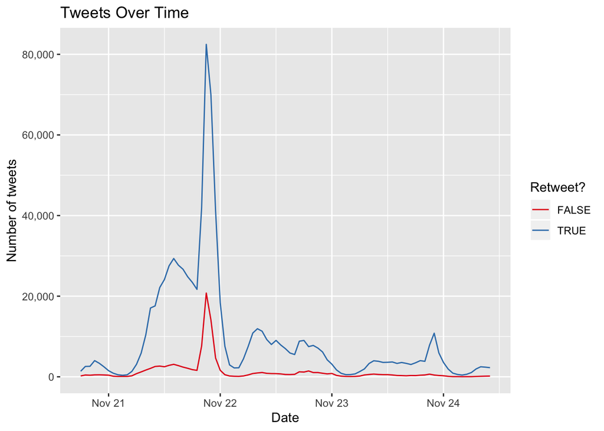

```r
tweets_text_df %>%
  count(created_at_round_hour, is_retweet) %>%
  ggmyplot(mapping = aes(x = created_at_round_hour, y = n, color = is_retweet)) +
  geom_line() +
  labs(title = "Tweets Over Time", colour= "Retweet?")  +
  xlab("Date") +
  ylab("Number of tweets") +
  scale_y_continuous(labels = scales::comma)
```

## Top Hashtags

Next we analyze the time development of the most popular hashtags:

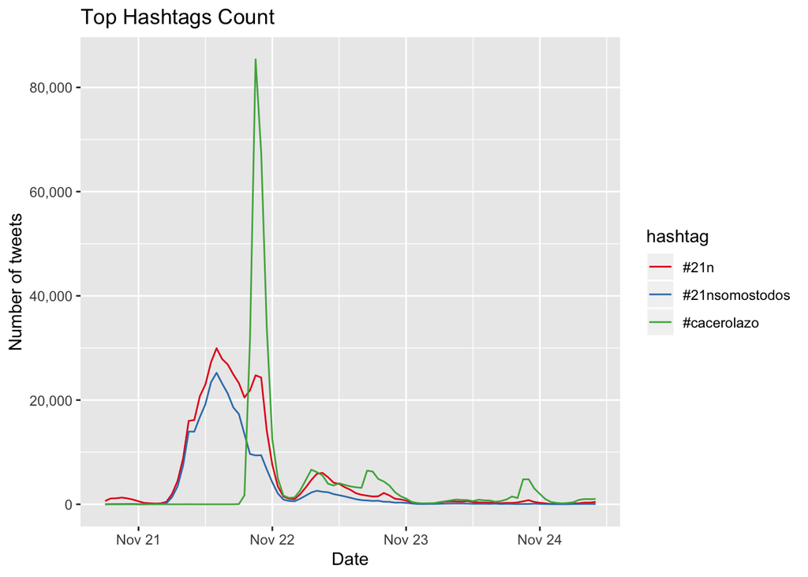

```r
top_hashtags <- hashtags_count_df %>% head(3) %>% pull(hashtag)
top_hashtags <- str_c("#", top_hashtags)

top_hashtags %>% map_df(
  .f = ~ get_text_over_time(tweets_text_df = tweets_text_df, txt_pattern = .x, no_hashtag = FALSE) %>%
    mutate(hashtag = .x)
  ) %>%
  ggmyplot(mapping = aes(x = created_at_round_hour, y =n, color = hashtag)) +
  geom_line() +
  labs(title = "Top Hashtags Count") +
  xlab("Date") +
  ylab("Number of tweets") +
  scale_y_continuous(labels = scales::comma)
```

We clearly see two clusters defining the two main activities driving the content of the tweets:

- The protests of the 21N.
- The cacerolazo.

## Word Count

Next we do some initial descriptive statistics on the words used in the tweets (removing the hashtags).

```r
stopwords_df <- tibble(word = stopwords::stopwords(language = "es"))

words_df <- tweets_text_df %>%
  unnest_tokens(output = word, input = clean_text_no_hashtag) %>%
  anti_join(y = stopwords_df, by = "word")

word_count <- words_df %>%
  count(word) %>%
  arrange(- n)
```

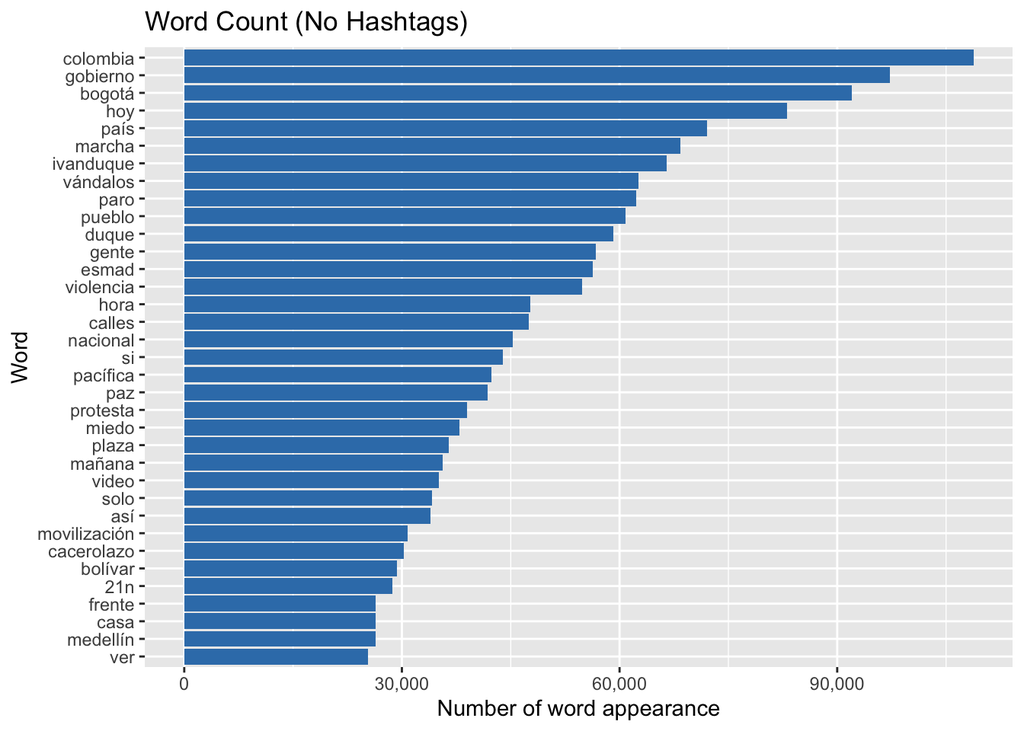

```r
word_count %>%
  mutate(word = reorder(word, n)) %>%
  head(35) %>%
  ggmyplot(mapping = aes(x = word, y = n)) +
  geom_col(fill = PALETTE_SET1[2]) +
  coord_flip() +
  labs(title = "Word Count (No Hashtags)") +
  ylab("Number of word appearance") +
  xlab("Word") +
  scale_y_continuous(labels = scales::comma)
```

Let us visualize this as a word cloud:

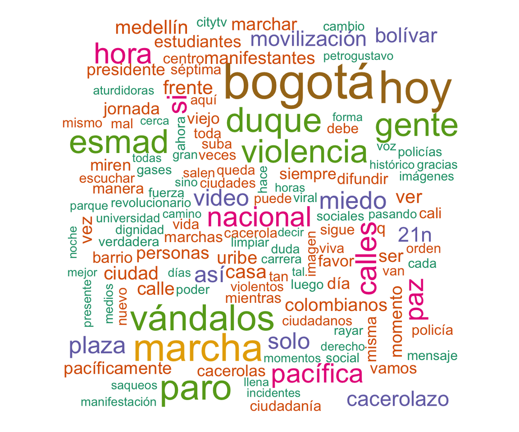

```r
wordcloud(
  words = head(word_count, 1000)$word,
  freq = head(word_count, 1000)$n,
  min.freq = 10000,
  colors = brewer.pal(8, "Dark2"))
```

Let us now do a similar word count but cfiltering only the tweets that contain a specific word defining a topic.

- Marcha (Protest)

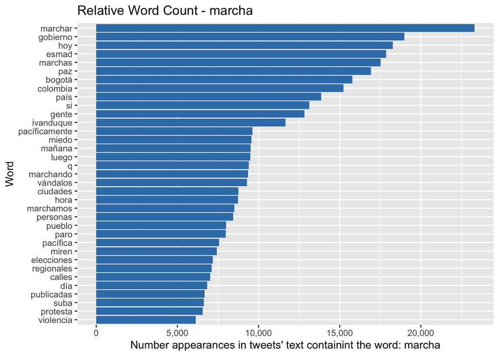

```r
input_word <- "marcha"

relative_word_count <- get_relatve_word_count(
  tweets_text_df = tweets_text_df,
  stopwords_df = stopwords_df,
  input_word = input_word
)

relative_word_count %>%
  mutate(word = reorder(word, n)) %>%
  head(35) %>%
  ggmyplot(mapping = aes(x = word, y = n)) +
  geom_col(fill = PALETTE_SET1[2]) +
  coord_flip() +
  labs(title = glue::glue("Relative Word Count - {input_word}")) +
  ylab(glue::glue("Number appearances in tweets' text containint the word: {input_word}")) +
  xlab("Word") +
  scale_y_continuous(labels = scales::comma)
```

Let us see the time development of some of the top words of this ranking:

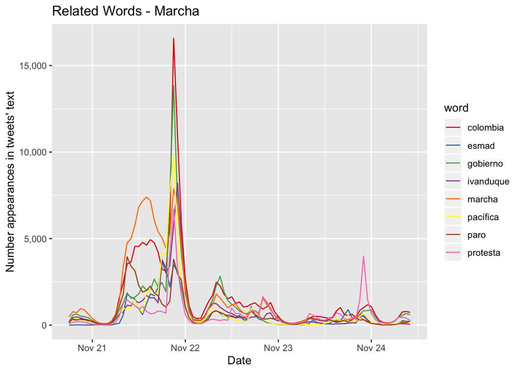

```r
words_vect <- c(
  "marcha",
  "gobierno",
  "ivanduque",
  "colombia",
  "protesta",
  "esmad",
  "paro",
  "pacífica"
)

words_vect %>% map_df(
  .f = ~ get_text_over_time(tweets_text_df = tweets_text_df, txt_pattern = .x, no_hashtag = TRUE) %>%
    mutate(word = .x)
  ) %>%
  ggmyplot(mapping = aes(x = created_at_round_hour, y = n, color = word)) +
  geom_line() +
  labs(title = "Related Words - Marcha") +
  ylab("Number appearances in tweets' text") +
  xlab("Date") +
  scale_y_continuous(labels = scales::comma)
```

Here are some observations:

- It is interesting that the word “gobierno” (government) is more present during the cacerolazo than during the protest period itself. This suggest that the people were making specific mentions about and to the government during at the time they were tweeting about the cacerolazo.
- This is also the case for the word “pacífica” (peaceful). The cacerolazo was seen as a peaceful response to the violent way the protest ended in the plaza de bolivar, which could help explain the association between the two words.
- Cacerolazo

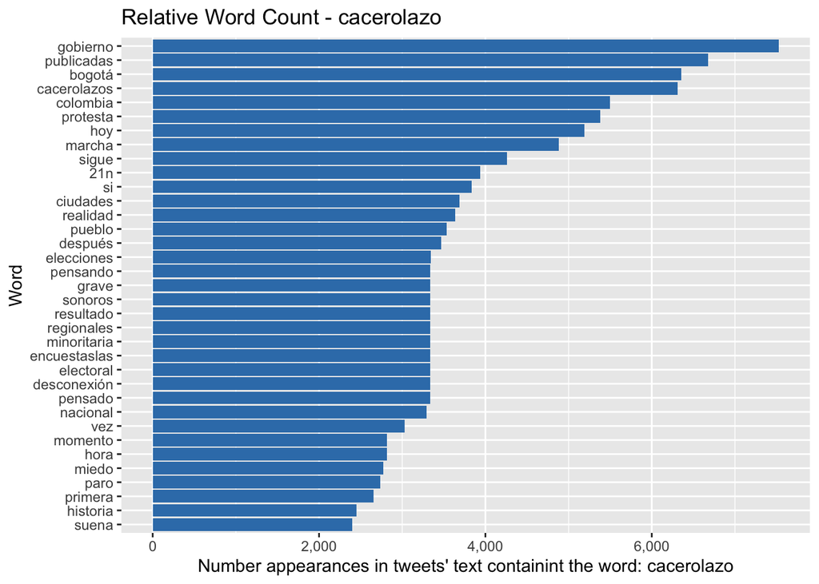

```r
input_word <- "cacerolazo"

relative_word_count <- get_relatve_word_count(
  tweets_text_df = tweets_text_df,
  stopwords_df = stopwords_df,
  input_word = input_word
)

relative_word_count %>%
  mutate(word = reorder(word, n)) %>%
  head(35) %>%
  ggmyplot(mapping = aes(x = word, y = n)) +
  geom_col(fill = PALETTE_SET1[2]) +
  coord_flip() +
  labs(title = glue::glue("Relative Word Count - {input_word}")) +
  ylab(glue::glue("Number appearances in tweets' text containint the word: {input_word}")) +
  xlab("Word") +
  scale_y_continuous(labels = scales::comma)
```

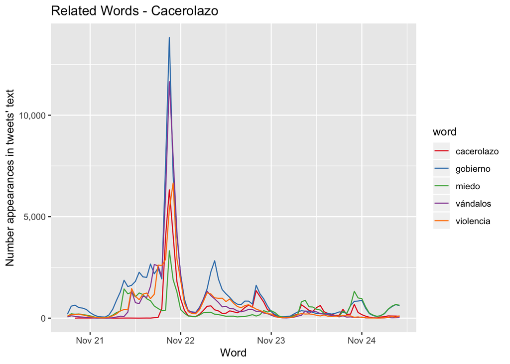

```r
words_vect <- c(
  "cacerolazo",
  "gobierno",
  "violencia",
  "miedo",
  "vándalos"
)

words_vect %>% map_df(
  .f = ~ get_text_over_time(tweets_text_df = tweets_text_df, txt_pattern = .x, no_hashtag = TRUE) %>%
    mutate(word = .x)
  ) %>%
  ggmyplot(mapping = aes(x = created_at_round_hour, y = n, color = word)) +
  geom_line() +
  labs(title = "Related Words - Cacerolazo") +
  ylab("Number appearances in tweets' text") +
  xlab("Word") +
  scale_y_continuous(labels = scales::comma)
```

Here are some observations:

Let us see the mentions of Colombian cities:

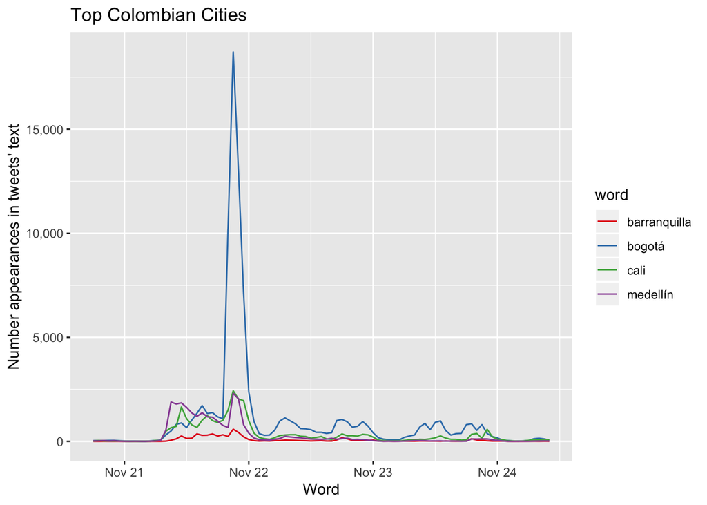

```r
words_vect <- c(
  "barranquilla",
  "bogotá",
  "cali",
  "medellín"
)

words_vect %>% map_df(
  .f = ~ get_text_over_time(tweets_text_df = tweets_text_df, txt_pattern = .x, no_hashtag = TRUE) %>%
    mutate(word = .x)
  ) %>%
  ggmyplot(mapping = aes(x = created_at_round_hour, y = n, color = word)) +
  geom_line() +
  labs(title = "Top Colombian Cities") +
  ylab("Number appearances in tweets' text") +
  xlab("Word") +
  scale_y_continuous(labels = scales::comma)
```

Bogota is clearly dominating.

## Topic Modeling

### LDA

```r
# Create a Document-Tem-Matrix
tweets_text_dtm <- tweets_text_df %>%
  select(clean_text_no_hashtag) %>%
  rowid_to_column() %>%
  unnest_tokens(input = clean_text_no_hashtag, output = "word") %>%
  anti_join(y = stopwords_df, by = "word") %>%
  count(rowid, word) %>%
  cast_dtm(document = rowid, term = word, value = n)

tweets_text_dtm
```

```r
# Train model.
lda_model <- LDA(x = tweets_text_dtm, k = 3, control = list(seed = 42))

topics_df <- tidy(x = lda_model, matrix ="beta")
```

```r
# Plot top terms per topic.
topic_top_terms <- topics_df %>%
  group_by(topic) %>%
  top_n(30, beta) %>%
  ungroup() %>%
  arrange(topic, -beta)

topic_top_terms %>%
  mutate(term = reorder_within(term, beta, topic)) %>%
  ggmyplot(mapping = aes(term, beta, fill = factor(topic))) +
  geom_col(show.legend = FALSE) +
  facet_wrap(~ topic, scales = "free") +
  coord_flip() +
  scale_x_reordered()
```

[output not shown]

Topic modeling (in my experience) does not work very well with social media data.

### Text Networks

Count the noumber of pairwise ocurrence per post.

```r
abs_pairwise_count_df <- tweets_text_df %>%
  select(clean_text) %>%
  rowid_to_column() %>%
  unnest_tokens(output = word, input = clean_text) %>%
  anti_join(y = stopwords_df, by = "word") %>%
  pairwise_count(item = word, feature = rowid) %>%
  filter(item1 < item2) %>% arrange(item1, item2) %>%
  rename(weight = n) %>%
  arrange(- weight)
```

Define a text graph. We wet a threshold to control noise.

```r
weight_threshold <- 3000

abs_pairwise_graph <- graph_from_data_frame(
  d = filter(abs_pairwise_count_df, weight > weight_threshold),
  directed = FALSE
)
```

We just consider the biggest connected component.

```r
E(abs_pairwise_graph)$weight_log <- log(E(abs_pairwise_graph)$weight)

V(abs_pairwise_graph)$component <- clusters(graph = abs_pairwise_graph)$membership

V(abs_pairwise_graph)$degree <- strength(graph = abs_pairwise_graph)

mask_top <- which(V(abs_pairwise_graph)$component == which.max(clusters(graph = abs_pairwise_graph)$csize))

top_abs_pairwise_graph <- induced_subgraph(
  graph = abs_pairwise_graph,
  vids = mask_top
)
```

Run community detection algorithm to detect topics.

```r
louvain_obj <- cluster_louvain(
  graph = top_abs_pairwise_graph,
  weights = E(top_abs_pairwise_graph)$weight
)

V(top_abs_pairwise_graph)$membership <- membership(communities = louvain_obj)

length(unique(V(top_abs_pairwise_graph)$membership))
```

```
## [1] 10
```

Plot graph:

```r
pdf("../images/abs_count_graph.pdf")

# Compute the weight shares.
E(top_abs_pairwise_graph)$width <- E(top_abs_pairwise_graph)$weight_log/max(E(top_abs_pairwise_graph)$weight_log)

 plot(
  top_abs_pairwise_graph,
  vertex.color = V(top_abs_pairwise_graph)$membership,
  vertex.frame.color = V(top_abs_pairwise_graph)$membership,
  # Scale node size by degree.
  vertex.size = V(top_abs_pairwise_graph)$degree / 1E6,
  vertex.label.color = "black",
  vertex.label.cex = 0.12,
  vertex.label.dist = 0.12,
  edge.color = "gray",
  # Set edge width proportional to the weight relative value.
  edge.width = (0.01)*E(top_abs_pairwise_graph)$width ,
  main = '21N - Twitter',
  sub = "Word Network - Topics",
  alpha = 50,
  palette = c(PALETTE_SET1, "deepskyblue")
)
dev.off()
```

Get topic summary.

[output not shown]

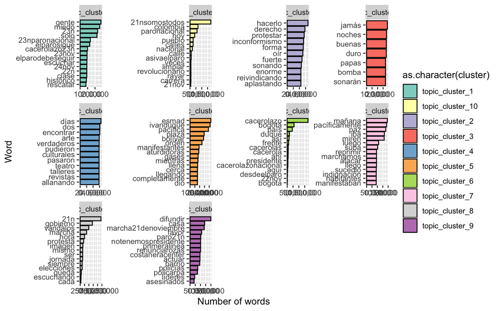

```r
membership_df <- tibble(
  word = names(V(top_abs_pairwise_graph)),
  cluster = str_c("topic_cluster_", as.character(V(top_abs_pairwise_graph)$membership)),
  degree = V(top_abs_pairwise_graph)$degree
)

membership_df %>%
  pull(cluster) %>%
  unique() %>%
  sort() %>%
  map_df(.f = function(cluster_id) {

    membership_df %>%
      filter(cluster == cluster_id) %>%
      head(15)
  }) %>%
  mutate(word = reorder(word, degree)) %>%
  ggmyplot(mapping = aes(x = word, y = degree, fill = as.character(cluster))) +
  geom_col(color = "black") +
  coord_flip() +
  facet_wrap(facets = ~ cluster, scales = "free") +
  scale_fill_brewer(palette = "Set3") +
  ylab("Number of words") +
  xlab("Word") +
  scale_y_continuous(labels = scales::comma)
```